# Marginalization of discrete parameters

## Overview

For the differential expression / differential translational efficiency modeling project, I’m concerned that marginalizing the discrete parameters representing per-tag null status damages the model’s performance in identifying null tags.

To explore this, I implemented two simplified mixture models, each in two different ways:

1. Marginalizing the discrete parameters representing class membership out of the model
2. Retaining the discrete parameters representing class membership

I compared estimated class probabilities and treatment effects between the two implementations; they look quite similar, which I think is evidence against my concern.

Creating this comparison felt helpful to me, and wasn’t a lot of work. I’m thinking of continuing to compare a few more models with and without marginalization, increasing the similarity to the Poisson GLMM used for the DE / DTE model that’s having problems.

## Simplified models

Since I wanted to examine the effects of marginalization without the complicated features of the DE / DTE model, I implemented these two models:

1. Two-class mixture of Normals
2. Two-class mixture of Normals with groups

### Model 1

The $i$’th observation may be affected by the treatment or not. The parameters $D_i$ represent whether or not $y_i$ is affected; if $D_i = 0$, the treatment has no effect on $y_i$.

$y_i \sim Normal(\mu_i, \sigma^2)$

$\mu_i = \beta_0 + x_i * \beta_1 * D_i$

### Model 2

Extends model 1 by adding groups (imitating tags in the DE / DTE model). The $g$’th group may be affected by the treatment or not. The $D_g$ parameters represent whether or not the treated observations in group $g$ are affected.

$y_{gi} \sim Normal(\mu_{gi}, \sigma^2)$

$\mu_{gi} = \beta_{g0} + x_i * \beta_{g1} * D_g$

## Comparisons of the implementations

### Model 2

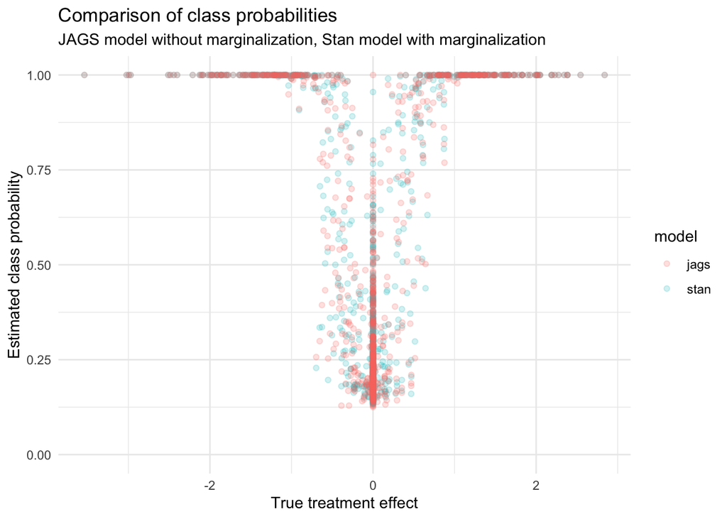

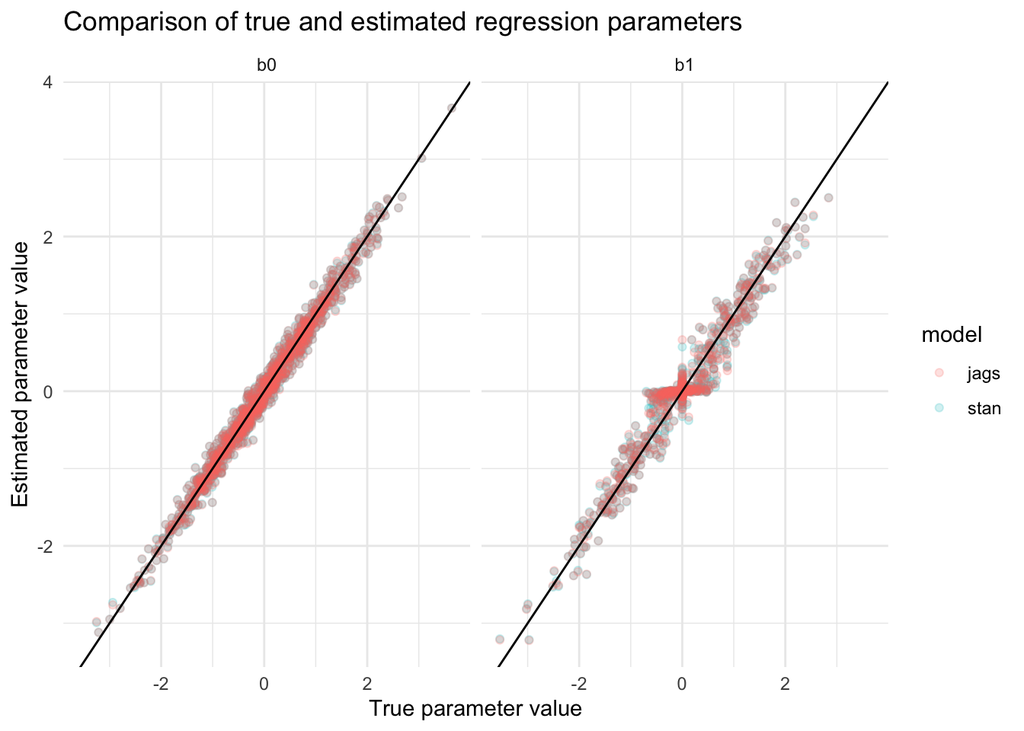